# Geelite Data Visualization

- Show All Code
- Hide All Code
- View Source

Author

M. Melik Kolgesiz

# Preface

This document presents a comprehensive analysis of vegetation dynamics across Turkey using MODIS NDVI (Normalized Difference Vegetation Index) data accessed through the geeLite R package. The analysis covers the period from 2020 to 2025, providing insights into spatial and temporal patterns of vegetation health and change.

## Load the necessary libraries

We begin by loading the essential R packages required for this analysis. These libraries provide functionality for data manipulation, spatial analysis, interactive mapping, and statistical visualization.

```r
library(ggplot2)
library(dplyr)
library(sf)
library(leaflet)
library(geeLite)
library(DT)
library(tidyr)
library(htmlwidgets)
```

## Load the geeLite database and spatial dataframe

We load the pre-processed geeLite database containing MODIS NDVI data for Turkey. The database must be ready for analysis, having been created through the geeLite workflow which downloads and processes Earth Engine data into a local SQLite database. The spatial data is merged with the hexagonal grid system for geographic visualization.

```r
# Load geeLite database with proper path
db <- read_db(path = "../data/tr-geelite", freq = "month")

# Load spatial data directly from geeLite database
sf_data <- merge(db$grid, db$`MODIS/061/MOD13A2/NDVI/mean`, by = "id")
```

## Process data frame for visualization

This section transforms the spatial data into formats suitable for time series analysis and visualization. We extract date columns, reshape the data from wide to long format, and calculate summary statistics for each time period including mean, median, and variability measures across all hexagonal grid cells.

```r
# Get date columns for NDVI data (exclude metadata columns)
date_cols <- colnames(sf_data)[!colnames(sf_data) %in% c("id", "iso", "aggregation", "postprocess", "geometry")]

# Prepare data for time slicing
sf_long <- sf_data %>%
  st_drop_geometry() %>%
  select(id, all_of(date_cols)) %>%
  tidyr::pivot_longer(cols = all_of(date_cols), names_to = "date", values_to = "ndvi") %>%
  mutate(date = as.Date(date))

# Calculate summary statistics by time period
ndvi_summary <- sf_long %>%
  group_by(date) %>%
  summarise(
    mean_ndvi = mean(ndvi, na.rm = TRUE),
    median_ndvi = median(ndvi, na.rm = TRUE),
    min_ndvi = min(ndvi, na.rm = TRUE),
    max_ndvi = max(ndvi, na.rm = TRUE),
    std_ndvi = sd(ndvi, na.rm = TRUE),
    valid_cells = sum(!is.na(ndvi)),
    .groups = "drop"
  )
```

## Interactive Leaflet Map with time slice

Following the World Bank blog approach, we created an interactive map that visualizes NDVI values across Turkey. Different time periods can be seen how vegetation patterns change over time.

```r
# Create a function to generate maps for different time periods
create_ndvi_map <- function(selected_date, data = sf_data, cols = date_cols) {
  ndvi_values <- data[[selected_date]]
  valid_ndvi <- ndvi_values[!is.na(ndvi_values)]

  # Create color palette with explicit domain range
  pal <- colorNumeric("viridis", domain = range(valid_ndvi, na.rm = TRUE))

  # Create leaflet map following blog example
  leaflet(data) %>%
    addTiles() %>%
    addPolygons(
      fillColor = ~pal(ndvi_values),
      weight = 1,
      color = "#333333",
      fillOpacity = 0.9,
      popup = ~paste("NDVI:", round(ndvi_values, 1),
                    "<br>Date:", selected_date,
                    "<br>Hex ID:", id)
    ) %>%
    addScaleBar() %>%
    addLegend(
      pal = pal,
      values = ~ndvi_values,
      title = paste("NDVI", selected_date),
      na.label = "No data",
      position = "bottomright"
    )
}

# Create maps for several key time periods
sample_dates <- c("2020-01-01", "2021-07-01", "2023-01-01", "2024-07-01", "2025-06-01")
available_dates <- intersect(sample_dates, date_cols)
```

### Interactive Maps by Time Period

The following tabbed interface displays interactive maps for five key time periods, allowing comparison of vegetation patterns across different seasons and years. Each map uses a viridis color scheme where darker colors indicate lower NDVI values (less vegetation) and brighter colors indicate higher NDVI values (more vegetation).

**2020-01-01**

```r
create_ndvi_map("2020-01-01")
```

[interactive chart not shown]

**2021-07-01**

```r
create_ndvi_map("2021-07-01")
```

[interactive chart not shown]

**2023-01-01**

```r
create_ndvi_map("2023-01-01")
```

[interactive chart not shown]

**2024-07-01**

```r
create_ndvi_map("2024-07-01")
```

[interactive chart not shown]

**2025-06-01**

```r
create_ndvi_map("2025-06-01")
```

[interactive chart not shown]

## Time Series Analysis

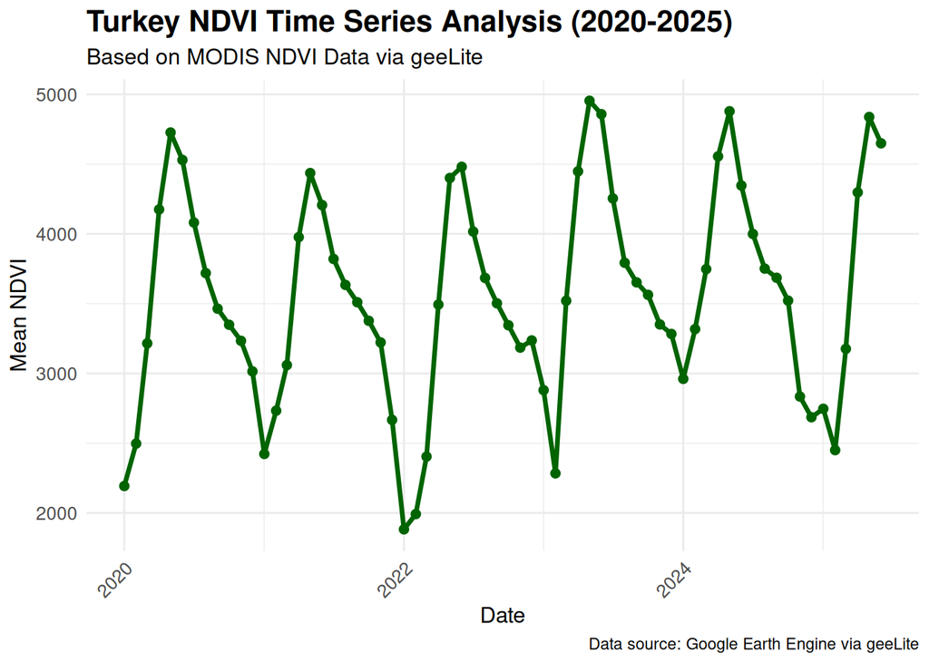

```r
# Create time series plot of mean NDVI values
p1 <- ggplot(ndvi_summary, aes(x = date, y = mean_ndvi)) +
  geom_line(color = "darkgreen", linewidth = 1.2) +
  geom_point(color = "darkgreen", size = 2) +
  labs(
    title = "Turkey NDVI Time Series Analysis (2020-2025)",
    subtitle = "Based on MODIS NDVI Data via geeLite",
    x = "Date",
    y = "Mean NDVI",
    caption = "Data source: Google Earth Engine via geeLite"
  ) +
  theme_minimal() +
  theme(
    plot.title = element_text(size = 16, face = "bold"),
    plot.subtitle = element_text(size = 12),
    axis.title = element_text(size = 12),
    axis.text = element_text(size = 10),
    axis.text.x = element_text(angle = 45, hjust = 1)
  )

print(p1)
```

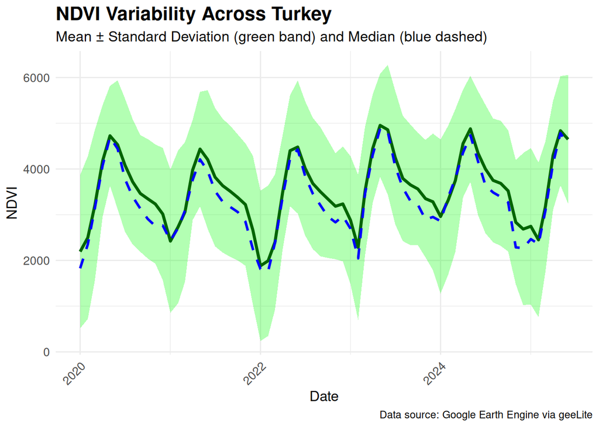

```r
# Create plot showing NDVI variability over time
p2 <- ggplot(ndvi_summary, aes(x = date)) +
  geom_ribbon(aes(ymin = mean_ndvi - std_ndvi, ymax = mean_ndvi + std_ndvi),
              alpha = 0.3, fill = "green") +
  geom_line(aes(y = mean_ndvi), color = "darkgreen", linewidth = 1.2) +
  geom_line(aes(y = median_ndvi), color = "blue", linewidth = 1, linetype = "dashed") +
  labs(
    title = "NDVI Variability Across Turkey",
    subtitle = "Mean ± Standard Deviation (green band) and Median (blue dashed)",
    x = "Date",
    y = "NDVI",
    caption = "Data source: Google Earth Engine via geeLite"
  ) +
  theme_minimal() +
  theme(
    plot.title = element_text(size = 16, face = "bold"),
    plot.subtitle = element_text(size = 12),
    axis.title = element_text(size = 12),
    axis.text = element_text(size = 10),
    axis.text.x = element_text(angle = 45, hjust = 1)
  )

print(p2)
```

## Summary Statistics

This section provides comprehensive statistical summaries of the NDVI analysis, including key metrics about data coverage, temporal scope, and overall vegetation trends. The summary table presents essential findings in a structured format for easy interpretation.

```r
# Calculate overall statistics
baseline_ndvi <- ndvi_summary$mean_ndvi[1]
latest_ndvi <- tail(ndvi_summary$mean_ndvi, 1)
total_change <- latest_ndvi - baseline_ndvi
mean_change_per_period <- mean(diff(ndvi_summary$mean_ndvi), na.rm = TRUE)

# Create summary table
summary_stats <- data.frame(
  Metric = c("Analysis Period", "Total Observations", "Hexagonal Cells",
             "Baseline NDVI", "Latest NDVI", "Total Change",
             "Average Change per Period", "Overall Trend"),
  Value = c(
    paste(min(ndvi_summary$date), "to", max(ndvi_summary$date)),
    format(nrow(sf_long), big.mark = ","),
    nrow(sf_data),
    round(baseline_ndvi, 1),
    round(latest_ndvi, 1),
    round(total_change, 1),
    round(mean_change_per_period, 2),
    ifelse(total_change > 50, "Vegetation Improvement",
           ifelse(total_change < -50, "Vegetation Decline", "Stable"))
  )
)

# Display summary table
knitr::kable(summary_stats,
             caption = "Turkey NDVI Analysis Summary",
             col.names = c("Metric", "Value"))
```

Turkey NDVI Analysis Summary

| Metric | Value |
| --- | --- |
| Analysis Period | 2020-01-01 to 2025-06-01 |
| Total Observations | 3,828 |
| Hexagonal Cells | 58 |
| Baseline NDVI | 2193 |
| Latest NDVI | 4649.2 |
| Total Change | 2456.2 |
| Average Change per Period | 37.79 |
| Overall Trend | Vegetation Improvement |

### Interactive Data Explorer

The interactive table below allows detailed exploration of the time series data. Users can search, sort, and filter the monthly NDVI statistics to identify specific patterns or periods of interest. The table includes statistical measures for each time period across all hexagonal grid cells.

```r
# Create interactive data table
DT::datatable(
  ndvi_summary %>%
    mutate(
      Date = format(date, "%Y-%m-%d"),
      `Mean NDVI` = round(mean_ndvi, 1),
      `Median NDVI` = round(median_ndvi, 1),
      `Min NDVI` = round(min_ndvi, 1),
      `Max NDVI` = round(max_ndvi, 1),
      `Std Dev` = round(std_ndvi, 1),
      `Valid Cells` = valid_cells
    ) %>%
    select(-date, -mean_ndvi, -median_ndvi, -min_ndvi, -max_ndvi, -std_ndvi, -valid_cells),
  caption = "Turkey NDVI Time Series Data",
  options = list(
    pageLength = 15,
    scrollX = TRUE,
    dom = 'Bfrtip'
  ),
  rownames = FALSE
)
```

| Date | Mean NDVI | Median NDVI | Min NDVI | Max NDVI | Std Dev | Valid Cells |
| --- | --- | --- | --- | --- | --- | --- |
| 2020-01-01 | 2193 | 1827.8 | -318.4 | 5710.2 | 1676.1 | 58 |
| 2020-02-01 | 2496.9 | 2350.5 | -379.1 | 5921.2 | 1779 | 58 |
| 2020-03-01 | 3215.3 | 3150.8 | -103.8 | 6138.1 | 1641.9 | 58 |
| 2020-04-01 | 4175 | 4073.8 | 1166.4 | 6292 | 1221.7 | 58 |
| 2020-05-01 | 4726.7 | 4695 | 2530.5 | 7399.4 | 1090.6 | 58 |
| 2020-06-01 | 4530 | 4441.7 | 1744.4 | 7867.4 | 1408.3 | 58 |
| 2020-07-01 | 4081.5 | 3776.7 | 1988.4 | 7712 | 1455.3 | 58 |
| 2020-08-01 | 3718.9 | 3393 | 2017.2 | 7477.1 | 1369.8 | 58 |
| 2020-09-01 | 3463.9 | 3132.5 | 1914.4 | 7011.2 | 1275.1 | 58 |
| 2020-10-01 | 3348.8 | 2907.9 | 1625.3 | 6503.1 | 1306.3 | 58 |

[output cut: 56 more lines]

## Key Findings

### Analysis Results

The following table summarizes the key quantitative findings from our analysis, including data coverage metrics, temporal scope, NDVI value ranges, and overall vegetation change assessment based on the comparison between baseline and latest observations.

```r
# Create results summary data frame
baseline_ndvi <- ndvi_summary$mean_ndvi[1]
latest_ndvi <- tail(ndvi_summary$mean_ndvi, 1)
total_change <- latest_ndvi - baseline_ndvi

results_summary <- data.frame(
  Metric = c("Data Coverage", "Time Period", "NDVI Range", "Baseline NDVI",
             "Latest NDVI", "Total Change", "Assessment"),
  Value = c(
    paste(nrow(sf_data), "hexagonal cells across Turkey"),
    paste(length(date_cols), "monthly observations from", min(date_cols), "to", max(date_cols)),
    paste(round(min(sf_long$ndvi, na.rm = TRUE)), "to", round(max(sf_long$ndvi, na.rm = TRUE))),
    paste(round(baseline_ndvi, 1), "(", min(date_cols), ")"),
    paste(round(latest_ndvi, 1), "(", max(date_cols), ")"),
    paste(round(total_change, 1), "NDVI units"),
    case_when(
      total_change > 50 ~ "VEGETATION IMPROVEMENT DETECTED 🌱",
      total_change < -50 ~ "VEGETATION DECLINE DETECTED ⚠️",
      TRUE ~ "Vegetation levels appear stable"
    )
  )
)

knitr::kable(results_summary, col.names = c("**Metric**", "**Value**"))
```

[output not shown]

### Methodology

This analysis uses the geeLite R package to analyze MODIS NDVI data from Google Earth Engine. The data is aggregated into hexagonal grid cells covering Turkey, with monthly time series from 2020 to 2025. Interactive maps allow exploration of spatial and temporal patterns in vegetation health across the country.

## References

1. **World Bank Data Team.** (2024). *geeLite – an R package for tracking remote sensing data locally*. World Bank Blogs - Open Data. Available at: https://blogs.worldbank.org/en/opendata/geelite–an-r-package-for-tracking-remote-sensing-datalocally-
2. **Braaten, J., Bullock, E., & Gorelick, N.** (2024). *geeLite: Client for Accessing and Processing Google Earth Engine Data*. GitHub Repository. Available at: https://github.com/gee-community/geeLite
3. **Google Earth Engine Team.** (2024). *MODIS/061/MOD13A2: MODIS Terra Vegetation Indices 16-Day Global 1km*. Google Earth Engine Data Catalog. Available at: https://developers.google.com/earth-engine/datasets/catalog/MODIS_061_MOD13A2